title: “hw3_Darshana_Daga” author: “Darshana” date: “4/28/2021”

#### Question1

#### Reading data in and prepping the data

```r
dat <- read.csv("hw3_vio_crime_updated.csv")
head(dat)
```

```
##   state       communityname fold population householdsize racepctblack
## 1     8        Lakewoodcity    1       0.19          0.33         0.02
## 2    53         Tukwilacity    1       0.00          0.16         0.12
## 3    24        Aberdeentown    1       0.00          0.42         0.49
## 4    34 Willingborotownship    1       0.04          0.77         1.00
## 5    42   Bethlehemtownship    1       0.01          0.55         0.02
## 6     6   SouthPasadenacity    1       0.02          0.28         0.06
##   racePctWhite racePctAsian racePctHisp agePct12t21 agePct12t29 agePct16t24
## 1         0.90         0.12        0.17        0.34        0.47        0.29
## 2         0.74         0.45        0.07        0.26        0.59        0.35
## 3         0.56         0.17        0.04        0.39        0.47        0.28
## 4         0.08         0.12        0.10        0.51        0.50        0.34
## 5         0.95         0.09        0.05        0.38        0.38        0.23
## 6         0.54         1.00        0.25        0.31        0.48        0.27
##   agePct65up numbUrban pctUrban medIncome pctWWage pctWFarmSelf pctWInvInc
```

[output cut: 118 more lines]

```r
str(dat)
```

```
## 'data.frame':    1993 obs. of  103 variables:
##  $ state                : int  8 53 24 34 42 6 44 6 21 29 ...
##  $ communityname        : chr  "Lakewoodcity" "Tukwilacity" "Aberdeentown" "Willingborotownship" ...
##  $ fold                 : int  1 1 1 1 1 1 1 1 1 1 ...
##  $ population           : num  0.19 0 0 0.04 0.01 0.02 0.01 0.01 0.03 0.01 ...
##  $ householdsize        : num  0.33 0.16 0.42 0.77 0.55 0.28 0.39 0.74 0.34 0.4 ...
##  $ racepctblack         : num  0.02 0.12 0.49 1 0.02 0.06 0 0.03 0.2 0.06 ...
##  $ racePctWhite         : num  0.9 0.74 0.56 0.08 0.95 0.54 0.98 0.46 0.84 0.87 ...
##  $ racePctAsian         : num  0.12 0.45 0.17 0.12 0.09 1 0.06 0.2 0.02 0.3 ...
##  $ racePctHisp          : num  0.17 0.07 0.04 0.1 0.05 0.25 0.02 1 0 0.03 ...
##  $ agePct12t21          : num  0.34 0.26 0.39 0.51 0.38 0.31 0.3 0.52 0.38 0.9 ...
##  $ agePct12t29          : num  0.47 0.59 0.47 0.5 0.38 0.48 0.37 0.55 0.45 0.82 ...
##  $ agePct16t24          : num  0.29 0.35 0.28 0.34 0.23 0.27 0.23 0.36 0.28 0.8 ...
##  $ agePct65up           : num  0.32 0.27 0.32 0.21 0.36 0.37 0.6 0.35 0.48 0.39 ...
##  $ numbUrban            : num  0.2 0.02 0 0.06 0.02 0.04 0.02 0 0.04 0.02 ...
```

[output cut: 86 more lines]

```r
dat1 <- dat[ -c(1:3) ] #removing the first 3 columns of the data
head(dat1)
```

```
##   population householdsize racepctblack racePctWhite racePctAsian racePctHisp
## 1       0.19          0.33         0.02         0.90         0.12        0.17
## 2       0.00          0.16         0.12         0.74         0.45        0.07
## 3       0.00          0.42         0.49         0.56         0.17        0.04
## 4       0.04          0.77         1.00         0.08         0.12        0.10
## 5       0.01          0.55         0.02         0.95         0.09        0.05
## 6       0.02          0.28         0.06         0.54         1.00        0.25
##   agePct12t21 agePct12t29 agePct16t24 agePct65up numbUrban pctUrban medIncome
## 1        0.34        0.47        0.29       0.32      0.20      1.0      0.37
## 2        0.26        0.59        0.35       0.27      0.02      1.0      0.31
## 3        0.39        0.47        0.28       0.32      0.00      0.0      0.30
## 4        0.51        0.50        0.34       0.21      0.06      1.0      0.58
## 5        0.38        0.38        0.23       0.36      0.02      0.9      0.50
## 6        0.31        0.48        0.27       0.37      0.04      1.0      0.52
##   pctWWage pctWFarmSelf pctWInvInc pctWSocSec pctWPubAsst pctWRetire medFamInc
```

[output cut: 118 more lines]

#### Descriptive statastics

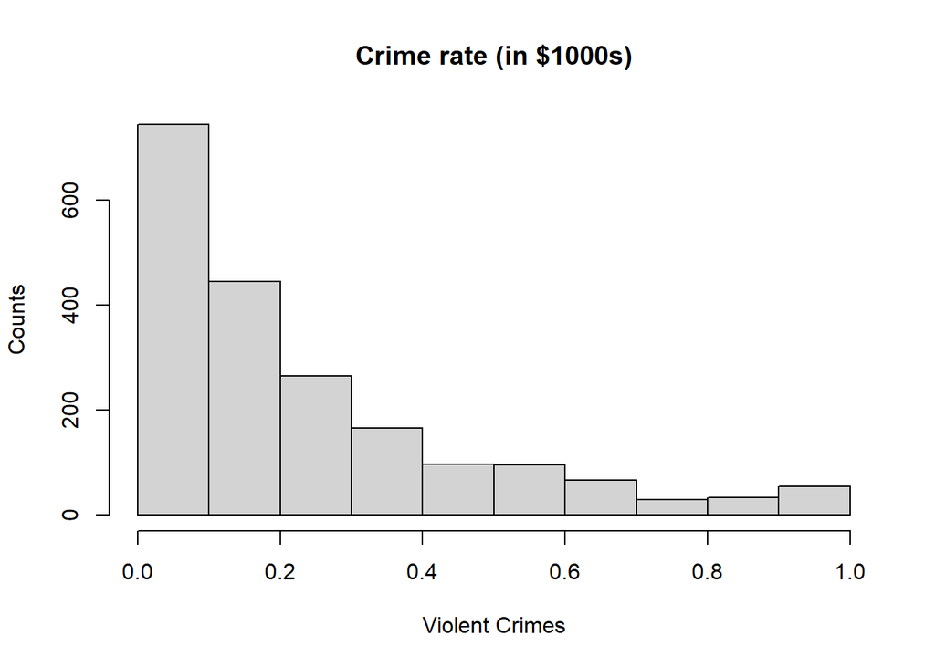

```r
hist(dat1$VioCrime, main = "Crime rate (in $1000s)",
     xlab = "Violent Crimes", ylab = "Counts")
```

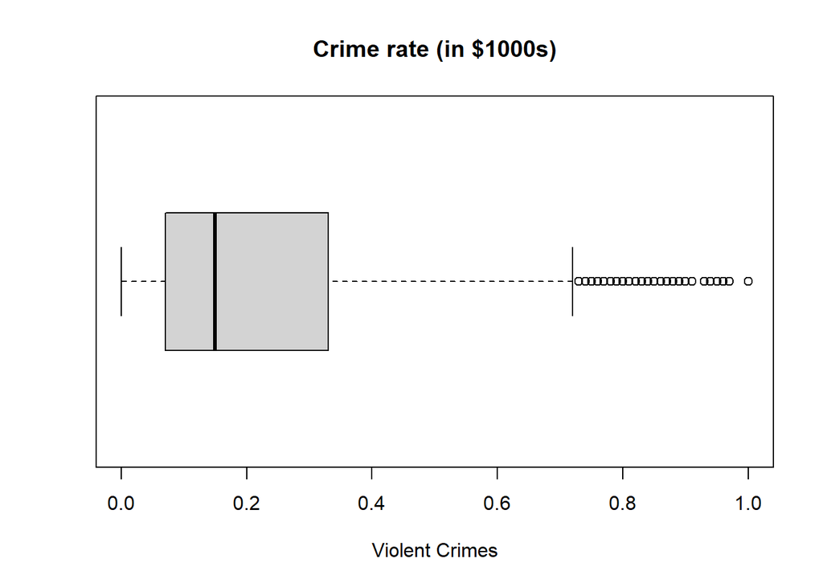

```r
boxplot(dat1$VioCrime, main = "Crime rate (in $1000s)",
        horizontal = T, xlab = "Violent Crimes")
```

#### Question 2

```r
options(scipen=999)
2^100
```

[output not shown]

#### Question 3

```r
library(leaps)
```

```r
reg3 <- regsubsets(VioCrime~.,data=dat1, nvmax = 100,
                         method = "forward", really.big = TRUE)

reg.summary <- summary(reg3)

#
#  Plot the diagnostic statistics computed by regsubsets
#  Plot adjusted R-squared, Mallows Cp and the Bayesian
#    Information Criterion (BIC)
#
par(mfrow=c(2,2))
plot(reg.summary$rsq, xlab = "Number of Variables", ylab ="R-squared")
plot(reg.summary$adjr2, xlab = "Number of Variables",
     ylab ="Adj R-squared")
which.max(reg.summary$adjr2)
```

```
## [1] 64
```

```r
maxar2 <- which.max(reg.summary$adjr2)
points(maxar2,reg.summary$adjr2[maxar2], col = "red", cex = 2, pch = 20)
plot(reg.summary$cp, xlab = "Number of Variables", ylab ="Mallows Cp")
which.min(reg.summary$cp)
```

```
## [1] 51
```

```r
mincp <- which.min(reg.summary$cp)
points(mincp,reg.summary$cp[mincp], col = "blue", cex = 2, pch = 20)
plot(reg.summary$bic, xlab = "Number of Variables",
     ylab ="Bayesian Info Crit")
which.min(reg.summary$bic)
```

```
## [1] 15
```

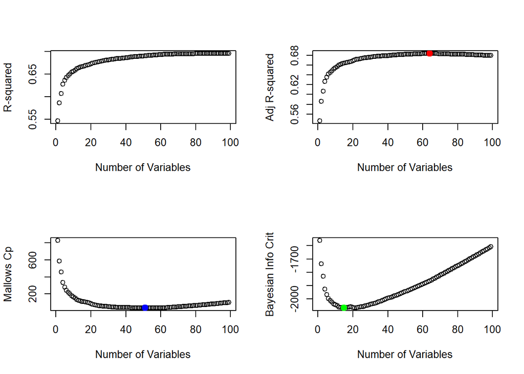

```r
minbic <- which.min(reg.summary$bic)
points(minbic,reg.summary$bic[minbic], col = "green", cex = 2, pch = 20)
```

```r
q3 <- data.frame(maxar2,mincp,minbic)
q3
```

```
##   maxar2 mincp minbic
## 1     64    51     15
```

After running the stepwise forward regression & evaluating the outcomes from Adjusted R-squared, Mallows Cp and BIC, it hard to make a judgment as all of them are pointing towards different sets of variable (Max AdjustedR:64, CP: 51,& BIC:15) Ideally the subset variable should make sense practically and have business implication. Machine alone cannot make decision, we need to understand the goal for the analysis and use the outcomes from machine as guidance. In this case, further analysis will be required to understand which variables are providing best business solution of correctly finding Violent crime numbers.

#### Question 4

```r
library(leaps)
regfit.fwd1 <- regsubsets(VioCrime~.,data=dat1, nvmax = 100,
                         method = "backward", really.big = TRUE)

reg.summary1 <- summary(regfit.fwd1)

par(mfrow=c(2,2))
plot(reg.summary1$rsq, xlab = "Number of Variables", ylab ="R-squared")
plot(reg.summary1$adjr2, xlab = "Number of Variables",
     ylab ="Adj R-squared")
which.max(reg.summary1$adjr2)
```

```
## [1] 58
```

```r
maxar3 <- which.max(reg.summary1$adjr2)
points(maxar3,reg.summary1$adjr2[maxar2], col = "red", cex = 2, pch = 20)
plot(reg.summary1$cp, xlab = "Number of Variables", ylab ="Mallows Cp")
which.min(reg.summary1$cp)
```

```
## [1] 49
```

```r
mincp1 <- which.min(reg.summary1$cp)
points(mincp1,reg.summary1$cp[mincp1], col = "blue", cex = 2, pch = 20)
plot(reg.summary1$bic, xlab = "Number of Variables",
     ylab ="Bayesian Info Crit")
which.min(reg.summary1$bic)
```

```
## [1] 14
```

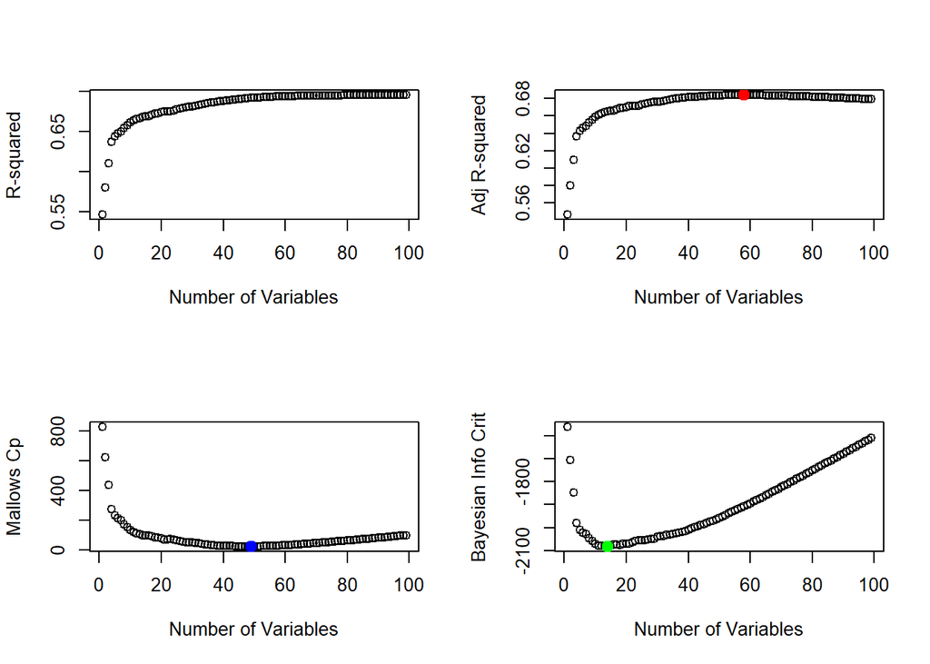

```r
minbic1 <- which.min(reg.summary1$bic)
points(minbic1,reg.summary1$bic[minbic1], col = "green", cex = 2, pch = 20)
```

```r
q4 <- data.frame(maxar3,mincp1,minbic1)
q4
```

```
##   maxar3 mincp1 minbic1
## 1     58     49      14
```

The variables for Max Adjusted R squared dropped from 64 to 58 when we ran a backward stepwise regression compared to forward stepwise regression. This seems sensitive for selecting ideal or ‘good’ subset. Also even though the Mallows Cp and Bayesian’s BIC also dropped to 49 and 14 variables for the subsets compared to 51 and 15 from forward stepwise regression respectively. It still not the best way to pick up variables to run a regression on certain subsets. Because, these evaluations just provide a ideal number of subsets of number ‘N’ and don’t give any information on as to which variables are going in these subsets for best accuracy. Hence, when comparing both the forward and backward stepwise regressions they are slightly different.

#### Question 5

```r
set.seed(100001)
train <- sample(nrow(dat1),nrow(dat1)/2)
dat.train <- dat1[train,]
dat.test <- dat1[-train,]

reg.train <- lm(VioCrime~ ., data = dat.train)
sum.train <- summary(reg.train)
sum.train$r.squared
```

```
## [1] 0.7168268
```

```r
train_p5 <- predict(reg.train, dat.train)
test_p5 <- predict(reg.train, dat.test)

RSS_Train5 <- sum((dat.train$VioCrime - train_p5)^2)
RSS_Test5 <- sum((dat.test$VioCrime - test_p5)^2)

MSE_Train5 <- RSS_Train5/(nrow(dat.train))
MSE_Test5 <- RSS_Test5/(nrow(dat.test))

RMSE_Train5 <- sqrt(MSE_Train5)
RMSE_Test5 <- sqrt(MSE_Test5)

tab5 <- matrix(c(RSS_Train5, MSE_Train5, RMSE_Train5,
                RSS_Test5, MSE_Test5, RMSE_Test5), ncol=2, byrow=FALSE)
options(scipen=999)
colnames(tab5) <- c("Training", "Test")
rownames(tab5) <- c("RSS", "MSE", "RMSE")
tab5
```

```
##         Training       Test
## RSS  14.72328254 20.0005195
## MSE   0.01478241  0.0200607
## RMSE  0.12158294  0.1416358
```

The R square for the current model on training data is 0.7168268. The RMSE for training data is 0.12158294 and for the test data is 0.1416358. Given the current numbers, over-fitting seems as an issue in he current model. The current model fits very well on training data and has an RMSE of 0.12158294, where as it increases on the test data to 0.1416358. It might not seem lot of difference initially, but it has to be kept in mind that the data is normalized and each point has much more weight. The model is over-fitting as well as biased towards the training data set.

#### Question 6

```r
#install.packages("boot")
library(boot)
glm1 <- glm(VioCrime~ ., data = dat1)
glm1_sum <- summary(glm1)
cv.err.5 <- cv.glm(dat1, glm1, K = 5)

MSE.5 <- cv.err.5$delta[2]
RMSE.5 <- MSE.5^0.5
#RMSE.5

cv.err.10 <- cv.glm(dat1, glm1, K = 10)
MSE.10 <- cv.err.10$delta[2]
RMSE.10 <- MSE.10^0.5
#RMSE.10

tab6 <- matrix(c(MSE.5, RMSE.5,
                MSE.10, RMSE.10), ncol=2, byrow=FALSE)
options(scipen=999)
colnames(tab6) <- c("Fold5", "Fold10")
rownames(tab6) <- c("MSE", "RMSE")
tab6
```

```
##           Fold5     Fold10
## MSE  0.01850625 0.01849923
## RMSE 0.13603767 0.13601188
```

#As k-fold creates kind of subsets, I used the whole data instead of train and #test data created previously.

The reason we don’t run LOOCV here is because the data is big and the way LOOCV performs, it leaves one out and calculates which will become computationally very expensive and time taking and wouldn’t be a optimal approach for such a big data set.

#### Question 7

```r
#install.packages("ISLR")
library(ISLR)
dat7 <- na.omit(dat1)

#install.packages("glmnet")
library(glmnet)
#
#  Set up our data into y and X
#    X is the design matrix without the intercept
#
y <- dat7$VioCrime
X <- model.matrix(VioCrime~., dat7)[,-1]
dim(X)
```

```
## [1] 1993   99
```

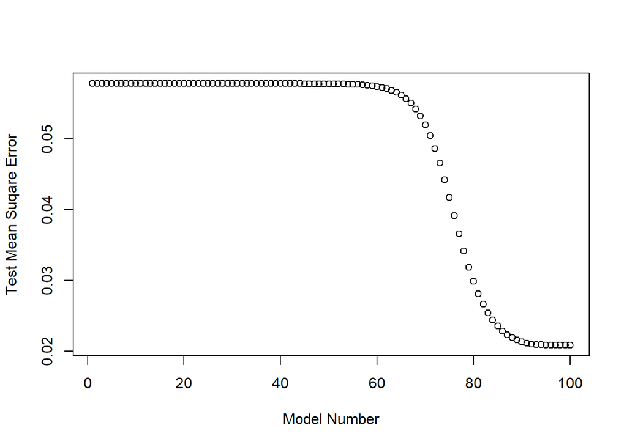

```r
grid <- 10^seq(10,-2,length=100)

set.seed(767676)
train <- sample(1:nrow(X), nrow(X)/2)
X.train <- X[train,]
y.train <- y[train]
X.test <- X[-train,]
y.test <- y[-train]

ridge.mod <- glmnet(X.train, y.train, alpha = 0,
                    lambda = grid, thresh = 1e-12)

ridge.coeff <- matrix(0, nrow = ncol(X), ncol = 100)
ridge.pred <- matrix(0,nrow = length(y.test), ncol = 100)
testerr <- matrix(0, nrow = 100, ncol = 1)

#
for (j in 1:100) {
  ridge.coeff[,j] <- ridge.mod$beta[,j]
  ridge.pred[,j] <- predict(ridge.mod, s = grid[j],
                            newx = X.test)
  testerr[j] <- mean((ridge.pred[,j] - y.test)^2)
}
#
#  Plot the test MSEs for the 100 models
#
plot(testerr, xlab = "Model Number",
     ylab = "Test Mean Suqare Error")
```

```r
best_lambada = grid[which.min(testerr)]
best_lambada
```

```
## [1] 0.0231013
```

```r
grid[97] #checking the lambda
```

```
## [1] 0.0231013
```

```r
#
testerr[97]
```

```
## [1] 0.02082097
```

```r
RMSE.train7 <- testerr[97]^0.5
RMSE.train7
```

```
## [1] 0.1442947
```

```r
ridge.mod2 <- glmnet(X.train, y.train, alpha = 0, lambada = best_lambda, thresh = 1e-12)
ridge.pred2 = predict(ridge.mod2, s = best_lambada, newx = X.test)
MSE.test7 <- mean((ridge.pred2 - y.test)^2)
MSE.test7
```

```
## [1] 0.02082086
```

```r
RMSE.test7 <- MSE.test7^0.5
RMSE.test7
```

```
## [1] 0.1442944
```

The MSE for test data is 0.02082086 and RMSE is 0.1442944.

#### Question 8

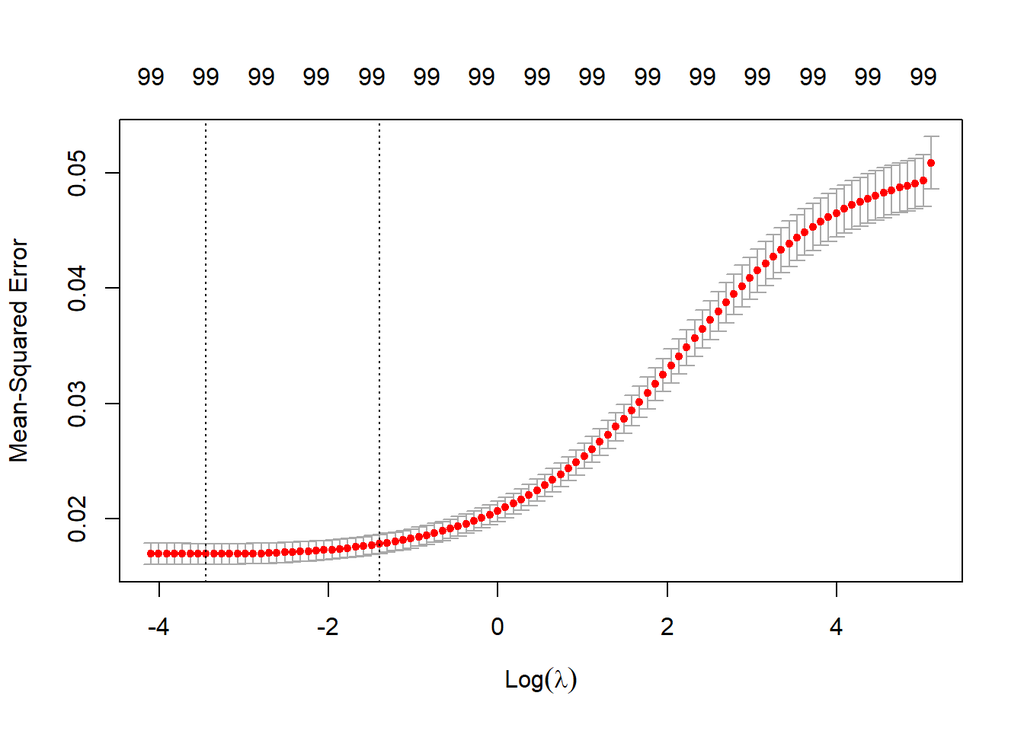

```r
cv.out <- cv.glmnet(X.train, y.train, alpha = 0)
plot(cv.out)
```

```r
bestlam = cv.out$lambda.min
bestlam
```

```
## [1] 0.03191927
```

```r
ridge8 <- glmnet(X.train, y.train, alpha = 0, lambda = bestlam)
ridge.pred8 <- predict(ridge8, s = bestlam, newx = X.test)
MSE8 <- mean((ridge.pred8 - y.test)^2)
RMSE8 <- MSE8^0.5
MSE8
```

```
## [1] 0.02084079
```

```r
RMSE8
```

```
## [1] 0.1443634
```

The MSE for test data is 0.02084079 and RMSE is 0.1443634.

#### Question 9

[figure not shown]

```r
lasso.mod <- glmnet(X.train, y.train, alpha=1,
                    lambda=bestlam, thresh = 1e-12)
plot(lasso.mod, xvar="lambda", label = TRUE)
```

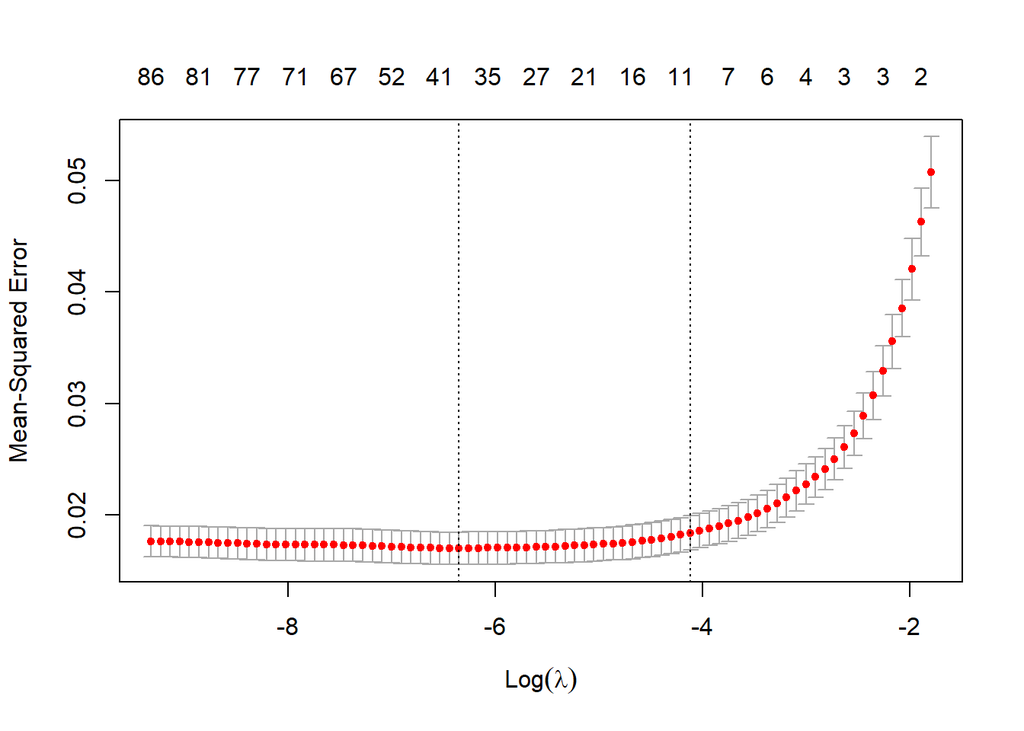

```r
cv.out1 <- cv.glmnet(X.train, y.train, alpha = 1)
plot(cv.out1)
```

```r
bestlam1 <- cv.out1$lambda.min
bestlam1
```

```
## [1] 0.001743519
```

```r
lasso.pred <- predict(lasso.mod, s=bestlam1,
                      newx = X.test)
MSE9 <- mean((lasso.pred-y.test)^2)
MSE9
```

```
## [1] 0.02358253
```

```r
RMSE9 <- MSE9^0.5
RMSE9
```

```
## [1] 0.153566
```